# Pandas and Friends

- Austin Godber
- Mail: godber@uberhip.com
- Twitter: @godber
- Presented at [DesertPy](http://desertpy.com), Jan 2015.

# What does it do?

Pandas is a Python data analysis tool built on top of NumPy that provides a suite of data structures and data manipulation functions to work on those data structures. It is particularly well suited for working with time series data.

# Getting Started - Installation

Installing with pip or apt-get::

```
pip install pandas
# or
sudo apt-get install python-pandas
```

- Mac - Homebrew or MacPorts to get the dependencies, then pip
- Windows - Python(x,y)?
- Commercial Pythons: Anaconda, Canopy

# Getting Started - Dependencies

Dependencies, required, recommended and optional

```
# Required
numpy, python-dateutil, pytx
# Recommended
numexpr, bottleneck
# Optional
cython, scipy, pytables, matplotlib, statsmodels, openpyxl
```

# Pandas' Friends!

Pandas works along side and is built on top of several other Python projects.

- IPython
- Numpy
- Matplotlib

## Pandas gets along with EVERYONE!

[figure not shown]

# Background - IPython

IPython is a fancy python console. Try running `ipython` or `ipython --pylab` on your command line. Some IPython tips

```
# Special commands, 'magic functions', begin with %
%quickref, %who, %run, %reset
# Shell Commands
ls, cd, pwd, mkdir
# Need Help?
help(), help(obj), obj?, function?
# Tab completion of variables, attributes and methods
```

# Background - IPython Notebook

There is a web interface to IPython, known as the IPython notebook, start it like this

```
ipython notebook
# or to get all of the pylab components
ipython notebook --pylab
```

# IPython - Follow Along

Follow along by connecting to TMPNB.ORG!

- http://tmpnb.org

# Background - NumPy

- NumPy is the foundation for Pandas
- Numerical data structures (mostly Arrays)
- Operations on those.
- Less structure than Pandas provides.

# Background - NumPy - Arrays

```python
import numpy as np
# np.zeros, np.ones
data0 = np.zeros((2, 4))

data0
```

```
array([[ 0.,  0.,  0.,  0.],
       [ 0.,  0.,  0.,  0.]])
```

```python
# Make an array with 20 entries 0..19
data1 = np.arange(20)
# print the first 8
data1[0:8]
```

```
array([0, 1, 2, 3, 4, 5, 6, 7])
```

## Background - NumPy - Arrays

```python
# make it a 4,5 array
data = np.arange(20).reshape(4, 5)
data
```

```
array([[ 0,  1,  2,  3,  4],
       [ 5,  6,  7,  8,  9],
       [10, 11, 12, 13, 14],
       [15, 16, 17, 18, 19]])
```

## Background - NumPy - Arrays

Arrays have NumPy specific types, `dtypes`, and can be operated on.

```python
print "dtype: ", data.dtype
result = data * 20.5
print result
```

```
dtype:  int64
[[   0.    20.5   41.    61.5   82. ]
 [ 102.5  123.   143.5  164.   184.5]
 [ 205.   225.5  246.   266.5  287. ]
 [ 307.5  328.   348.5  369.   389.5]]
```

## Now, on to Pandas

[figure not shown]

## Pandas

- Tabular, Timeseries, Matrix Data - labeled or not
- Sensible handling of missing data and data alignment
- Data selection, slicing and reshaping features
- Robust data import utilities.
- Advanced time series capabilities

## Data Structures

- Series - 1D labeled array
- DataFrame - 2D labeled array
- Panel - 3D labeled array (More D)

# Assumed Imports

In my code samples, assume I import the following

```python
import pandas as pd
import numpy as np
```

# Series

- one-dimensional labeled array
- holds any data type
- axis labels known as index
- implicit integert indexes
- `dict`-like

# Create a Simple Series

```python
s1 = pd.Series([1, 2, 3, 4, 5])
s1
```

```
0    1
1    2
2    3
3    4
4    5
dtype: int64
```

# Series Operations

```python
# integer multiplication
print s1 * 5
```

```
0     5
1    10
2    15
3    20
4    25
dtype: int64
```

# Series Operations - Cont.

```python
# float multiplication
print s1 * 5.0
```

```
0     5
1    10
2    15
3    20
4    25
dtype: float64
```

# Series Index

```python
s2 = pd.Series([1, 2, 3, 4, 5],
               index=['a', 'b', 'c', 'd', 'e'])
s2
```

```
a    1
b    2
c    3
d    4
e    5
dtype: int64
```

# Date Convenience Functions

A quick aside ...

```python
dates = pd.date_range('20130626', periods=5)
print dates
print
print dates[0]
```

```
<class 'pandas.tseries.index.DatetimeIndex'>
[2013-06-26, ..., 2013-06-30]
Length: 5, Freq: D, Timezone: None

2013-06-26 00:00:00
```

# Datestamps as Index

```python
s3 = pd.Series([1, 2, 3, 4, 5], index=dates)
print s3
```

```
2013-06-26    1
2013-06-27    2
2013-06-28    3
2013-06-29    4
2013-06-30    5
Freq: D, dtype: int64
```

# Selecting By Index

Note that the integer index is retained along with the new date index.

```python
print s3[0]
print type(s3[0])
print
print s3[1:3]
print type(s3[1:3])
```

```
1
<type 'numpy.int64'>

2013-06-27    2
2013-06-28    3
Freq: D, dtype: int64
<class 'pandas.core.series.Series'>
```

# Selecting by value

```python
s3[s3 < 3]
```

```
2013-06-26    1
2013-06-27    2
Freq: D, dtype: int64
```

# Selecting by Label (Date)

```python
s3['20130626':'20130628']
```

```
2013-06-26    1
2013-06-27    2
2013-06-28    3
Freq: D, dtype: int64
```

## Series Wrapup

Things not covered but you should look into:

- Other instantiation options: `dict`
- Operator Handling of missing data `NaN`
- Reforming Data and Indexes
- Boolean Indexing
- Other Series Attributes:
  - `index` - `index.name`
  - `name` - Series name

## DataFrame

- 2-dimensional labeled data structure
- Like a SQL Table, Spreadsheet or `dict` of `Series` objects.
- Columns of potentially different types
- Operations, slicing and other behavior just like `Series`

# DataFrame - Simple

```python
data1 = pd.DataFrame(np.random.rand(4, 4))
data1
```

|  | 0 | 1 | 2 | 3 |
| --- | --- | --- | --- | --- |
| 0 | 0.371333 | 0.788792 | 0.869380 | 0.084323 |
| 1 | 0.490858 | 0.134202 | 0.816307 | 0.019157 |
| 2 | 0.839547 | 0.721638 | 0.544628 | 0.042547 |
| 3 | 0.098594 | 0.954038 | 0.306561 | 0.689759 |

# DataFrame - Index/Column Names

```python
dates = pd.date_range('20130626', periods=4)
data2 = pd.DataFrame(
    np.random.rand(4, 4),
    index=dates, columns=list('ABCD'))
data2
```

|  | A | B | C | D |
| --- | --- | --- | --- | --- |
| 2013-06-26 | 0.572954 | 0.785437 | 0.089758 | 0.872083 |
| 2013-06-27 | 0.857868 | 0.779294 | 0.453022 | 0.836332 |
| 2013-06-28 | 0.715369 | 0.355922 | 0.750194 | 0.770045 |
| 2013-06-29 | 0.409056 | 0.452993 | 0.937368 | 0.118998 |

# DataFrame - Operations

```python
data2['E'] = data2['B'] + 5 * data2['C']
data2
```

|  | A | B | C | D | E |
| --- | --- | --- | --- | --- | --- |
| 2013-06-26 | 0.572954 | 0.785437 | 0.089758 | 0.872083 | 1.234225 |
| 2013-06-27 | 0.857868 | 0.779294 | 0.453022 | 0.836332 | 3.044402 |
| 2013-06-28 | 0.715369 | 0.355922 | 0.750194 | 0.770045 | 4.106891 |
| 2013-06-29 | 0.409056 | 0.452993 | 0.937368 | 0.118998 | 5.139832 |

See? You never need Excel again!

# DataFrame - Column Access

Deleting a column.

```python
# Deleting a Column
del data2['E']
data2
```

|  | A | B | C | D |
| --- | --- | --- | --- | --- |
| 2013-06-26 | 0.572954 | 0.785437 | 0.089758 | 0.872083 |
| 2013-06-27 | 0.857868 | 0.779294 | 0.453022 | 0.836332 |
| 2013-06-28 | 0.715369 | 0.355922 | 0.750194 | 0.770045 |
| 2013-06-29 | 0.409056 | 0.452993 | 0.937368 | 0.118998 |

# DataFrame

Remember this, data2, for the next examples.

```python
data2
```

|  | A | B | C | D |
| --- | --- | --- | --- | --- |
| 2013-06-26 | 0.572954 | 0.785437 | 0.089758 | 0.872083 |
| 2013-06-27 | 0.857868 | 0.779294 | 0.453022 | 0.836332 |
| 2013-06-28 | 0.715369 | 0.355922 | 0.750194 | 0.770045 |
| 2013-06-29 | 0.409056 | 0.452993 | 0.937368 | 0.118998 |

# DataFrame - Column Access

As a dict

```python
data2['B']
```

```
2013-06-26    0.785437
2013-06-27    0.779294
2013-06-28    0.355922
2013-06-29    0.452993
Freq: D, Name: B, dtype: float64
```

# DataFrame - Column Access

As an attribute

```python
data2.B
```

```
2013-06-26    0.785437
2013-06-27    0.779294
2013-06-28    0.355922
2013-06-29    0.452993
Freq: D, Name: B, dtype: float64
```

# DataFrame - Row Access

By row label

```python
data2.loc['20130627']
```

```
A    0.857868
B    0.779294
C    0.453022
D    0.836332
Name: 2013-06-27 00:00:00, dtype: float64
```

# DataFrame - Row Access

By integer location

```python
data2.iloc[1]
```

```
A    0.857868
B    0.779294
C    0.453022
D    0.836332
Name: 2013-06-27 00:00:00, dtype: float64
```

# DataFrame - Cell Access

Access column, then row or use iloc and row/column indexes.

```python
print data2.B[0]
print data2['B'][0]
print data2.iloc[0,1]  # [row,column]
```

```
0.785436968548
0.785436968548
0.785436968548
```

# DataFrame - Taking a Peek

Look at the beginning of the DataFrame

```python
data3 = pd.DataFrame(np.random.rand(100, 4))
data3.head()
```

|  | 0 | 1 | 2 | 3 |
| --- | --- | --- | --- | --- |
| 0 | 0.127258 | 0.981462 | 0.820096 | 0.650613 |
| 1 | 0.471623 | 0.118745 | 0.595012 | 0.205356 |
| 2 | 0.802777 | 0.398816 | 0.383789 | 0.025648 |
| 3 | 0.368724 | 0.922648 | 0.850099 | 0.659503 |
| 4 | 0.889618 | 0.565936 | 0.056413 | 0.768219 |

# DataFrame - Taking a Peek

Look at the end of the DataFrame.

```python
data3.tail()
```

|  | 0 | 1 | 2 | 3 |
| --- | --- | --- | --- | --- |
| 95 | 0.332815 | 0.920505 | 0.808580 | 0.161875 |
| 96 | 0.348941 | 0.532944 | 0.921147 | 0.736528 |
| 97 | 0.305776 | 0.747903 | 0.161359 | 0.808279 |
| 98 | 0.141267 | 0.878946 | 0.537137 | 0.157560 |
| 99 | 0.862024 | 0.519265 | 0.172454 | 0.665810 |

# DataFrame Wrap Up

Just remember,

- A `DataFrame` is just a bunch of `Series` grouped together.
- Any one dimensional slice returns a `Series`
- Any two dimensional slice returns another `DataFrame`.
- Elements are typically NumPy types or Objects.

# Panel

Like DataFrame but 3 or more dimensions.

# IO Tools

Robust IO tools to read in data from a variety of sources

- CSV - [pd.read_csv()](http://pandas.pydata.org/pandas-docs/stable/io.html#io-read-csv-table)
- Clipboard - [pd.read_clipboard()](http://pandas.pydata.org/pandas-docs/stable/io.html#clipboard)
- SQL - [pd.read_sql_table()](http://pandas.pydata.org/pandas-docs/stable/io.html#sql-queries)
- Excel - [pd.read_excel()](http://pandas.pydata.org/pandas-docs/stable/io.html#io-excel)

# Plotting

- Matplotlib - [s.plot()](http://pandas.pydata.org/pandas-docs/stable/visualization.html#plotting-with-matplotlib) - Standard Python Plotting Library
- Trellis - [rplot()](http://pandas.pydata.org/pandas-docs/stable/rplot.html) - An 'R' inspired Matplotlib based plotting tool

# Bringing it Together - Data

The csv file (`phx-temps.csv`) contains Phoenix weather data from GSOD::

```
1973-01-01 00:00:00,53.1,37.9
1973-01-02 00:00:00,57.9,37.0
...
2012-12-30 00:00:00,64.9,39.0
2012-12-31 00:00:00,55.9,41.0
```

# Bringing it Together - Code

Simple `read_csv()`

```python
# simple readcsv
phxtemps1 = pd.read_csv('phx-temps.csv')
phxtemps1.head()
```

|  | 1973-01-01 00:00:00 | 53.1 | 37.9 |
| --- | --- | --- | --- |
| 0 | 1973-01-02 00:00:00 | 57.9 | 37.0 |
| 1 | 1973-01-03 00:00:00 | 59.0 | 37.0 |
| 2 | 1973-01-04 00:00:00 | 57.9 | 41.0 |
| 3 | 1973-01-05 00:00:00 | 54.0 | 39.9 |
| 4 | 1973-01-06 00:00:00 | 55.9 | 37.9 |

# Bringing it Together - Code

Advanced `read_csv()`, parsing the dates and using them as the index, and naming the columns.

```python
# define index, parse dates, name columns
phxtemps2 = pd.read_csv(
    'phx-temps.csv', index_col=0,
    names=['highs', 'lows'], parse_dates=True)
phxtemps2.head()
```

|  | highs | lows |
| --- | --- | --- |
| 1973-01-01 | 53.1 | 37.9 |
| 1973-01-02 | 57.9 | 37.0 |
| 1973-01-03 | 59.0 | 37.0 |
| 1973-01-04 | 57.9 | 41.0 |
| 1973-01-05 | 54.0 | 39.9 |

# Bringing it Together - Plot

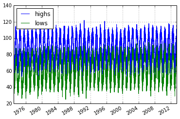

```python
import matplotlib.pyplot as plt
%matplotlib inline
phxtemps2.plot()  # pandas convenience method
```

Boo, Pandas and Friends would cry if they saw such a plot.

# Bringing it Together - Plot

Lets see a smaller slice of time:

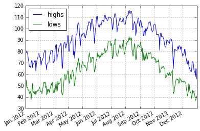

```python
phxtemps2['20120101':'20121231'].plot()
```

# Bringing it Together - Plot

Lets operate on the `DataFrame` ... lets take the differnce between the highs and lows.

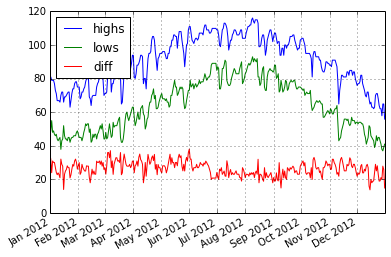

```python
phxtemps2['diff'] = phxtemps2.highs - phxtemps2.lows
phxtemps2['20120101':'20121231'].plot()
```

# Pandas Alternatives

- AstroPy seems to have similar data structures.
- I suspect there are others.

## References

- [Pandas Documentation](http://pandas.pydata.org/pandas-docs/stable/index.html)
- [Python for Data Analysis](http://www.amazon.com/Python-Data-Analysis-Wes-McKinney/dp/1449319793/)
- [Presentation Source](https://github.com/desertpy/presentations)

# Thanks! - Pandas and Friends

- Austin Godber
- Mail: godber@uberhip.com
- Twitter: @godber
- Presented at [DesertPy](http://desertpy.com), Jan 2015.